# Statistics of known oncogenes from COSMIC and oncoKB in our data

### Data preparation

Read data and leave only regions with known genes (data has been merged with oncogene containing datasets COSMIC and oncoKB + region thresholding and interval merging is done)

```r
data <- read.csv("../../Data/Processed_data/Table_COSMIC_oncoKB_oncogenes_TSG.csv")
data <- data[data$gene_name!="", ]

cancer_types <- read.csv("../../Data/Raw_data/Table_for_cancer_types.csv")
cancer_types <- cancer_types %>%
  select("name", "cancer_type")
data <- left_join(data, cancer_types, join_by("sample.x" == "name"))
```

### Let’s group data by cancer type and unique regions to see how many genes in our data are labeled as oncogenes

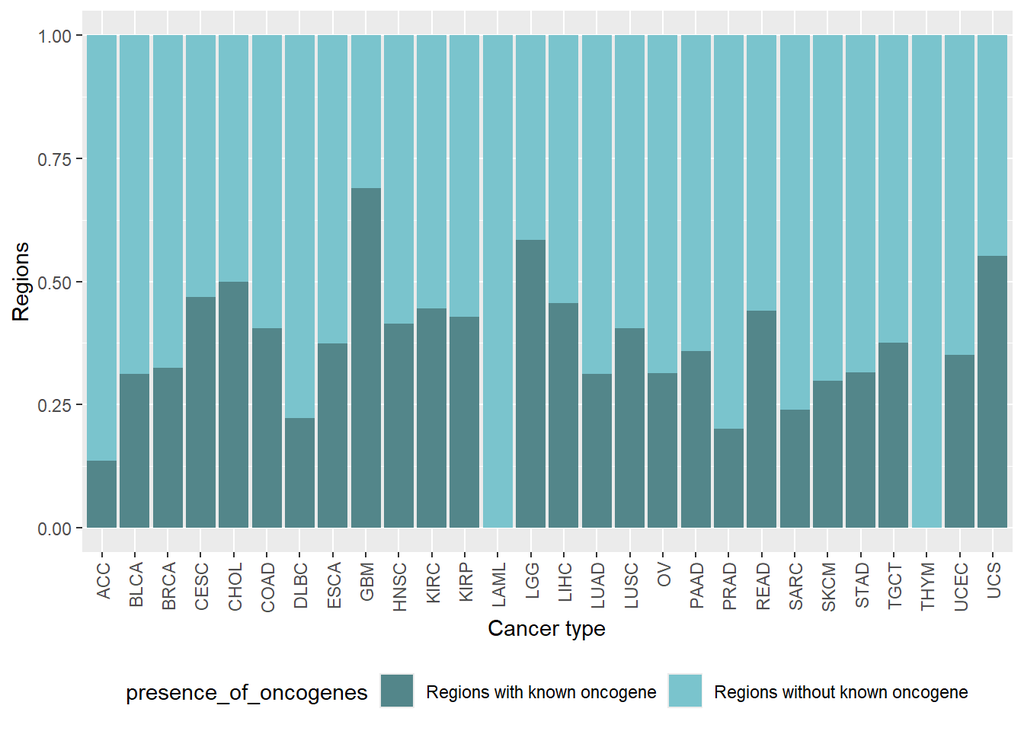

```r
data$coordinates <- paste(as.character(data$chr), ":", data$startpos, "-", data$endpos)

count_per_region <- data %>%
  group_by(cancer_type, coordinates) %>%
  summarize(
    n_oncogenes = sum(Role.in.Cancer.COSMIC %in% c("oncogene, fusion", "oncogene") | Is.Oncogene.oncoKB == "Yes")
  ) %>%
  ungroup()

count_per_region$oncogenes <- ifelse(count_per_region$n_oncogenes > 0, 1, 0)

summary_per_region <- count_per_region %>%
  group_by(cancer_type) %>%
  summarize(
    regions_with_at_least_one_oncogene = sum(oncogenes==1),
    regions_without_oncogenes = sum(oncogenes==0)
  ) %>%
  ungroup()

summary_per_region_long <- pivot_longer(summary_per_region, cols = c("regions_with_at_least_one_oncogene", "regions_without_oncogenes"), names_to = "presence_of_oncogenes", values_to = "Regions")


colnames(summary_per_region_long)[1] <- 'Cancer type'
summary_per_region_long$presence_of_oncogenes <- ifelse(summary_per_region_long$presence_of_oncogenes == 'regions_with_at_least_one_oncogene', 'Regions with known oncogene', 'Regions without known oncogene')

ggplot(summary_per_region_long, aes(fill=presence_of_oncogenes, y=Regions, x=`Cancer type`)) +
    geom_bar(position=position_fill(reverse = TRUE), stat="identity") +
  scale_fill_manual(values = c("Regions with known oncogene" = "#53868a", 'Regions without known oncogene' = "#7ac4cd")) +
  theme(axis.text.x = element_text(angle = 90, vjust = 0.5, hjust = 1),
        legend.position = "bottom")
```

This many regions over all cancers got at least one oncogene:

```r
sum(summary_per_region$regions_with_at_least_one_oncogene)
```

```
## [1] 2259
```

This many regions over all cancers got NO oncogenes from COSMIC or oncoKB:

```r
sum(summary_per_region$regions_without_oncogenes)
```

```
## [1] 3962
```

```r
sum(summary_per_region$regions_with_at_least_one_oncogene)*100/(sum(summary_per_region$regions_without_oncogenes)+ sum(summary_per_region$regions_with_at_least_one_oncogene))
```

```
## [1] 36.31249
```

```r
median(summary_per_region$regions_with_at_least_one_oncogene*100/(summary_per_region$regions_with_at_least_one_oncogene+summary_per_region$regions_without_oncogenes))
```

```
## [1] 36.63881
```

### Let’s group data by cancer type and sample to see how many genes in our data are labeled as oncogenes

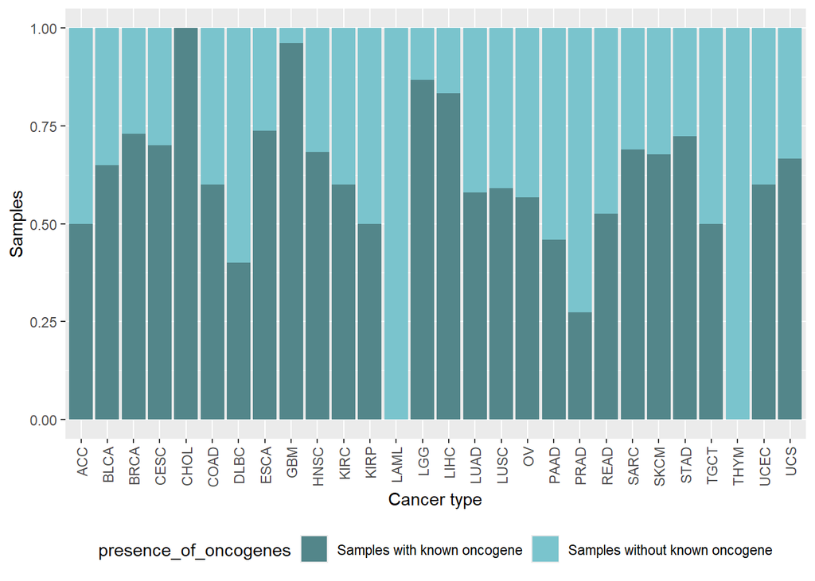

```r
cancer_sample_grouped_stats <- data %>%
  group_by(cancer_type, sample.x) %>%
  summarize(
    oncogenes = sum(Role.in.Cancer.COSMIC %in% c("oncogene, fusion", "oncogene") | Is.Oncogene.oncoKB == "Yes")
  )

cancer_sample_grouped_stats$oncogenes <- ifelse(cancer_sample_grouped_stats$oncogenes >0, 1, 0)

summary_per_samples <- cancer_sample_grouped_stats %>%
  group_by(cancer_type) %>%
  summarize(
    samples_with_at_least_one_onco = sum(oncogenes==1),
    samples_without_onco = sum(oncogenes==0)
  ) %>%
  ungroup()

summary_per_samples_long <- pivot_longer(summary_per_samples, cols = c("samples_with_at_least_one_onco", "samples_without_onco"), names_to = "presence_of_oncogenes", values_to = "Samples")


colnames(summary_per_samples_long)[1] <- 'Cancer type'
summary_per_samples_long$presence_of_oncogenes <- ifelse(summary_per_samples_long$presence_of_oncogenes == 'samples_with_at_least_one_onco', 'Samples with known oncogene', 'Samples without known oncogene')

ggplot(summary_per_samples_long, aes(fill=presence_of_oncogenes, y=Samples, x=`Cancer type`)) +
    geom_bar(position=position_fill(reverse = TRUE), stat="identity") +
  scale_fill_manual(values = c("Samples with known oncogene" = "#53868a", 'Samples without known oncogene' = "#7ac4cd")) +
  theme(axis.text.x = element_text(angle = 90, vjust = 0.5, hjust = 1),
        legend.position = "bottom")
```

```r
sum(summary_per_samples$samples_with_at_least_one_onco)*100/(sum(summary_per_samples$samples_with_at_least_one_onco)+ sum(summary_per_samples$samples_without_onco))
```

```
## [1] 70.46229
```

```r
median(summary_per_samples$samples_with_at_least_one_onco*100/(summary_per_samples$samples_with_at_least_one_onco+ summary_per_samples$samples_without_onco))
```

```
## [1] 60
```

### Acessing distribution of region length and copy number for regions with at least one oncogene and without

Of note: there are 3 regions that are exactly having the same borders within the same cancer type, but they are coming from different samples, their copy number is different. I take therefore mean of copy number. For other region it doesnt make any difference as they have only one sample.

It is:

GBM 7 : 55225629 - 55798100 has oncogene 22 and 42 copies

STAD 11 : 34666863 - 35709082 no oncogene 25 and 27 copies

UCEC 17 : 37671490 - 37974720 has oncogene 16 and 21 copies

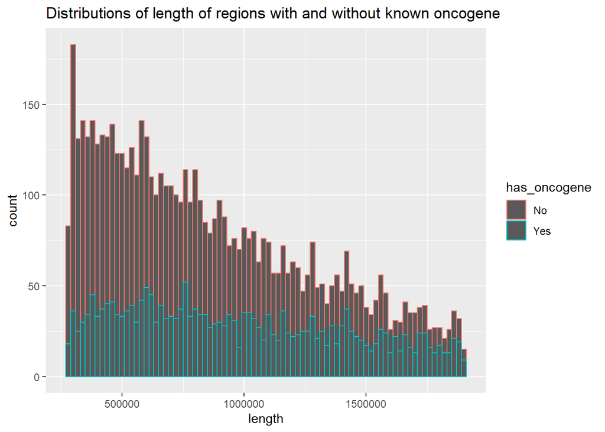

```r
count_per_region$coordinates_2 <- sub(".* : ", "", count_per_region$coordinates)
count_per_region <- separate(count_per_region, coordinates_2, into = c("start", "end"), sep = " - ")
count_per_region$start <- as.integer(count_per_region$start)
count_per_region$end <- as.integer(count_per_region$end)
count_per_region$length <- count_per_region$end - count_per_region$start
count_per_region <- count_per_region %>%
  mutate(has_oncogene = ifelse(oncogenes > 0, "Yes", "No"))
count_per_region$ID <- paste(count_per_region$cancer_type, count_per_region$coordinates)
data$ID <- paste(data$cancer_type, data$coordinates)

data_check <- data %>%
  group_by(ID) %>%
  summarize(
  nUniqueMajor = n_distinct(nMajor),
  copy_number = as.integer(mean(nMajor))
  ) %>%
  ungroup()

count_per_region <- left_join(count_per_region, data_check, by = "ID")

ggplot(count_per_region, aes(x=length, color=has_oncogene)) +
  geom_histogram(binwidth=20000) +
  ggtitle("Distributions of length of regions with and without known oncogene")
```

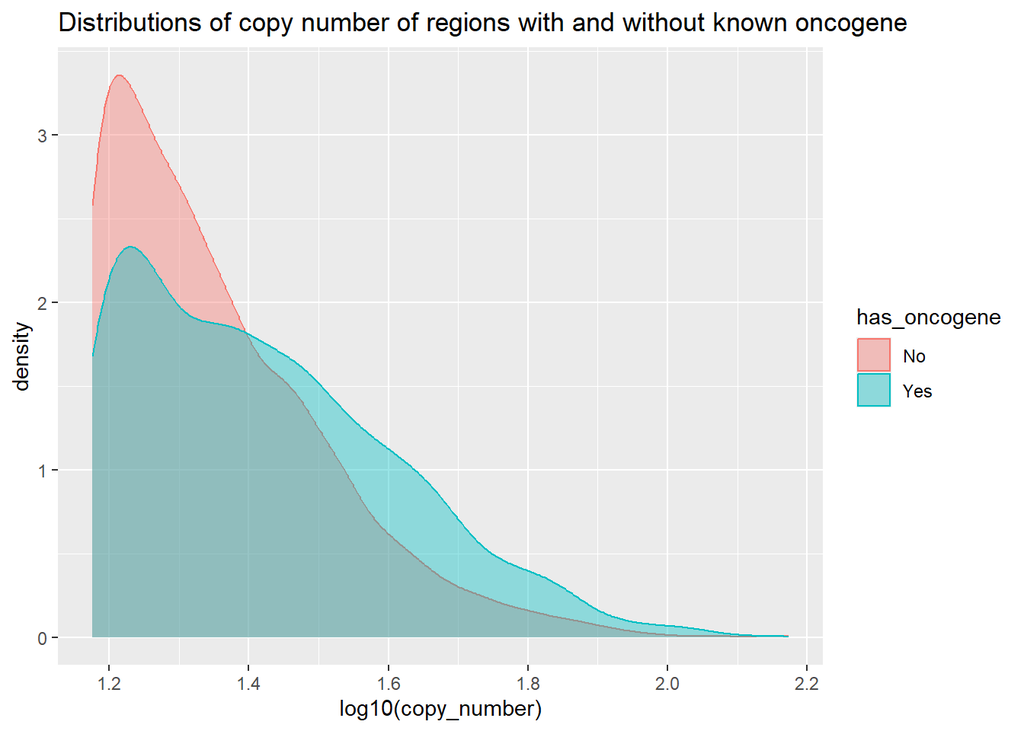

```r
ggplot(count_per_region, aes(x=log10(copy_number), color=has_oncogene, fill=has_oncogene))+
  geom_density(alpha=0.4) +
  ggtitle("Distributions of copy number of regions with and without known oncogene")
```

### Region length vs copy number

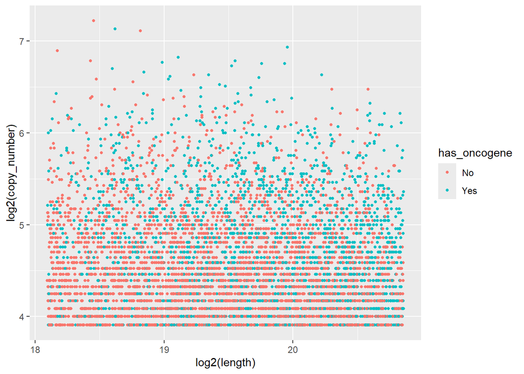

```r
ggplot(count_per_region, aes(x=log2(length), y=log2(copy_number), color=has_oncogene)) +
    geom_point(size=1)
```

### Distribution of number of oncogene per region

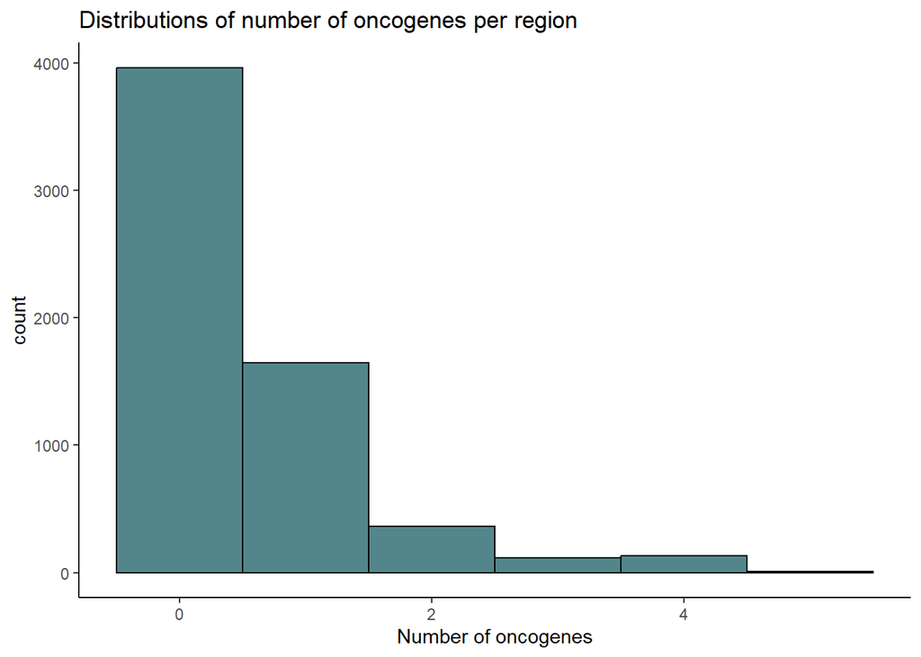

```r
ggplot(count_per_region, aes(x=n_oncogenes)) +
  geom_histogram(binwidth=1, fill = "#53868a", color = "black") +
  ggtitle("Distributions of number of oncogenes per region") +
  labs(x = "Number of oncogenes") +
  theme_classic()
```

```r
median(count_per_region$n_oncogenes)
```

```
## [1] 0
```

### Distribution of number of oncogene per sample

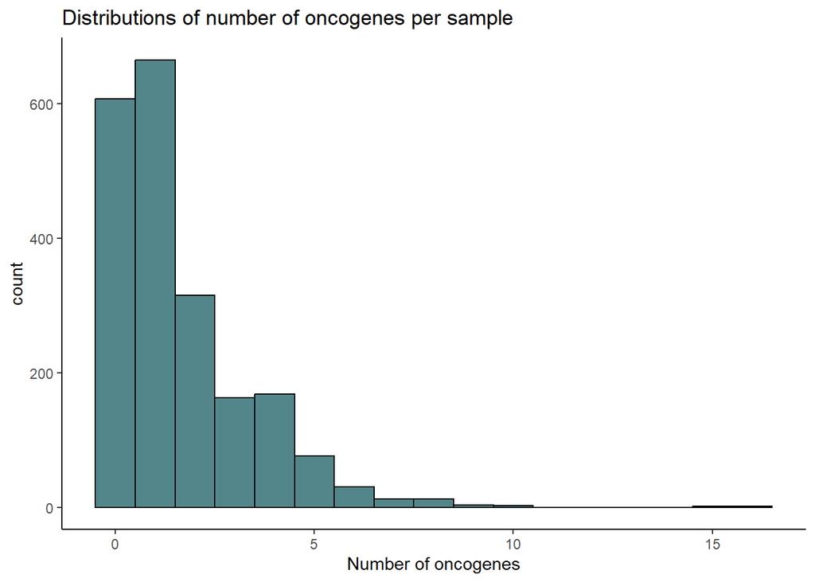

```r
count_per_sample <- data %>%
  group_by(cancer_type, sample.x) %>%
  summarize(
    oncogenes = sum(Role.in.Cancer.COSMIC %in% c("oncogene, fusion", "oncogene") | Is.Oncogene.oncoKB == "Yes")
  ) %>%
  ungroup()


ggplot(count_per_sample, aes(x=oncogenes)) +
  geom_histogram(binwidth=1, fill = "#53868a", color = "black") +
  ggtitle("Distributions of number of oncogenes per sample") +
  labs(x = "Number of oncogenes") +
  theme_classic()
```

```r
median(count_per_sample$oncogenes)
```

```
## [1] 1
```

All the exploratory statistic above was base on the oncogens present at least in one of the data bases.

### If there are multiple regions in the same sample are they likely to have one or many oncogenes

```r
cancer_sample_summary <- data %>%
  group_by(sample.x, cancer_type, coordinates) %>%
  summarize(
    n_oncogenes = sum(Role.in.Cancer.COSMIC %in% c("oncogene, fusion", "oncogene") | Is.Oncogene.oncoKB == "Yes")
  ) %>%
  ungroup()

cancer_sample_summary <- cancer_sample_summary %>%
  group_by(sample.x, cancer_type) %>%
  summarize(
    n_oncogenes = sum(n_oncogenes),
    n_regions = n()
  ) %>%
  ungroup()

cor.test(cancer_sample_summary$n_regions, cancer_sample_summary$n_oncogenes)
```

```
##
##  Pearson's product-moment correlation
##
## data:  cancer_sample_summary$n_regions and cancer_sample_summary$n_oncogenes
## t = 29.275, df = 2053, p-value < 2.2e-16
## alternative hypothesis: true correlation is not equal to 0
## 95 percent confidence interval:
##  0.5114466 0.5724916
## sample estimates:
##       cor
## 0.5426853
```

There seems to be moderate correlation between number of regions in the sample and number of oncogenes. Let’s see the graph:

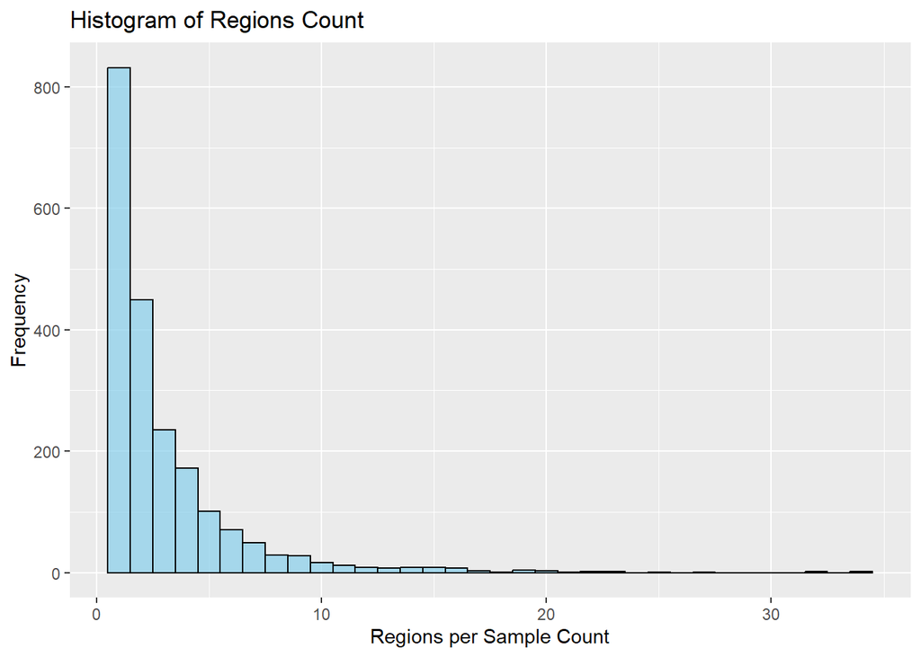

```r
ggplot(cancer_sample_summary, aes(x = n_regions)) +
  geom_histogram(binwidth = 1, fill = "skyblue", color = "black", alpha = 0.7) +
  labs(title = "Histogram of Regions Count",
       x = "Regions per Sample Count",
       y = "Frequency")
```

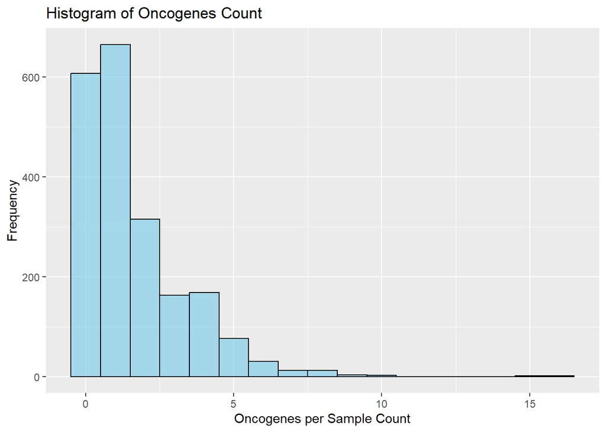

```r
ggplot(cancer_sample_summary, aes(x = n_oncogenes)) +
  geom_histogram(binwidth = 1, fill = "skyblue", color = "black", alpha = 0.7) +
  labs(title = "Histogram of Oncogenes Count",
       x = "Oncogenes per Sample Count",
       y = "Frequency")
```

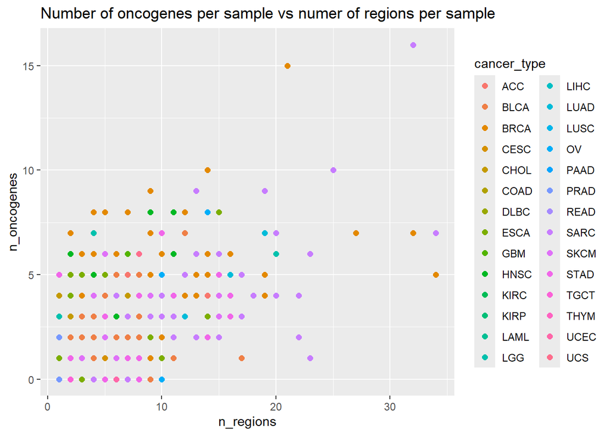

```r
ggplot(cancer_sample_summary, aes(x=n_regions, y=n_oncogenes, color=cancer_type)) +
    geom_point(size=2) +
    ggtitle("Number of oncogenes per sample vs numer of regions per sample")
```